# Data Preprocessing

HungTa Chen

2022-11-22

**Read in data**

```r
# Read the file
library(stringr)
data = read.csv("./ufc_data.csv")
```

**Preliminary clean**

Since a lot of weight classes that ufc has today were established after 2000, we drop all the fights before 2000. Also, all winners are recorded as red side before March 2010, which makes the data imbalance. Therefore, we drop all observations before that.

```r
data = data[1:4727, ]
```

Also, we remove the fights between fighters who has less than three fights in UFC, since those fights don’t have much reference value.

```r
newcomer_fights = which(((data$B_wins+data$B_losses) <= 3) | ((data$R_wins+data$R_losses) <= 3))
data = data[(-1)*newcomer_fights, ]
```

We drop some columns based on background knowledge

```r
# Drop some irrelevent columns
drop = c("R_fighter", "B_fighter", "Referee", "date", "location", "title_bout")
data_reduced = data[, !(colnames(data) %in% drop)]

# Drop columns related to previous opponents
opp_col = sapply(colnames(data_reduced), str_detect, regex("opp"))
data_reduced = data_reduced[, !(opp_col)]

# Omit rows with NA
data_reduced = na.omit(data_reduced)
```

Since in most cases both fighters fight in the same weight class, we can also drop “Weight” column.

```r
# Drop weight column
w_col = sapply(colnames(data_reduced), str_detect, regex("Weight"))
data_reduced = data_reduced[, !(w_col)]
```

Since “draw” rarely happens, almost every element in the column equals 0, so we can drop the columns of recorded draw..

```r
# Drop draw column
draw_col = sapply(colnames(data_reduced), str_detect, regex("draw"))
data_reduced = data_reduced[, !(draw_col)]
```

**Check categorical data**

First we check the proportion of each level in “Winner”.

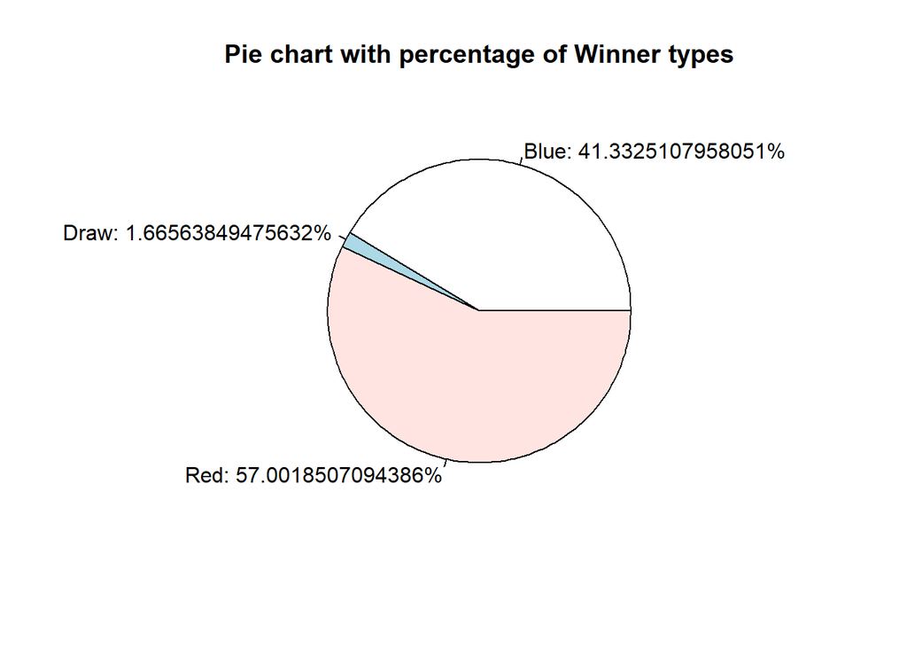

```r
n = nrow(data_reduced)
winner_type = levels(as.factor(data_reduced$Winner))
winner_percent = 100*table(data_reduced$Winner)/n
winner_lab = paste(winner_type, ": ", winner_percent, sep='')
winner_lab <- paste(winner_lab, '%', sep='')

pie(table(data_reduced$Winner),labels=winner_lab, main='Pie chart with percentage of Winner types')
```

Another fact is that the fights ending in a draw only account for less than 2%, so we drop all the rows whose “Winner” column is draw.

```r
data_reduced = data_reduced[data_reduced$Winner != "Draw",]
```

```r
# # Copy the entire dataset and swap everything related to Red and Blue
# data_switch = data_reduced[, c(1, 2, 43:82, 3:42, 83, 84)]
# colnames(data_switch) = colnames(data_reduced)
# blue_idx = data_reduced$Winner == "Blue"
# red_idx = data_reduced$Winner == "Red"
# data_switch$Winner[blue_idx] = "Red"
# data_switch$Winner[red_idx] = "Blue"
#
# # Concat the two dataframes
# data_reduced = rbind(data_reduced, data_switch)
```

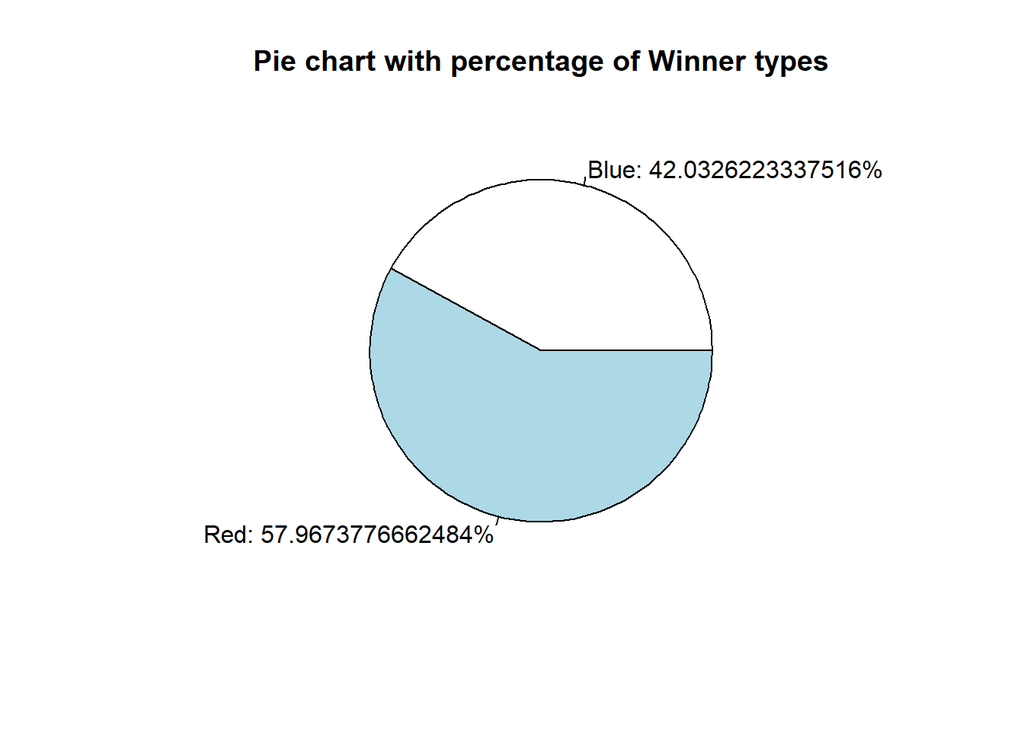

```r
n = nrow(data_reduced)
winner_type = levels(as.factor(data_reduced$Winner))
winner_percent = 100*table(data_reduced$Winner)/n
winner_lab = paste(winner_type, ": ", winner_percent, sep='')
winner_lab <- paste(winner_lab, '%', sep='')

pie(table(data_reduced$Winner),labels=winner_lab, main='Pie chart with percentage of Winner types')
```

Now we check the proportion of the “weight class”

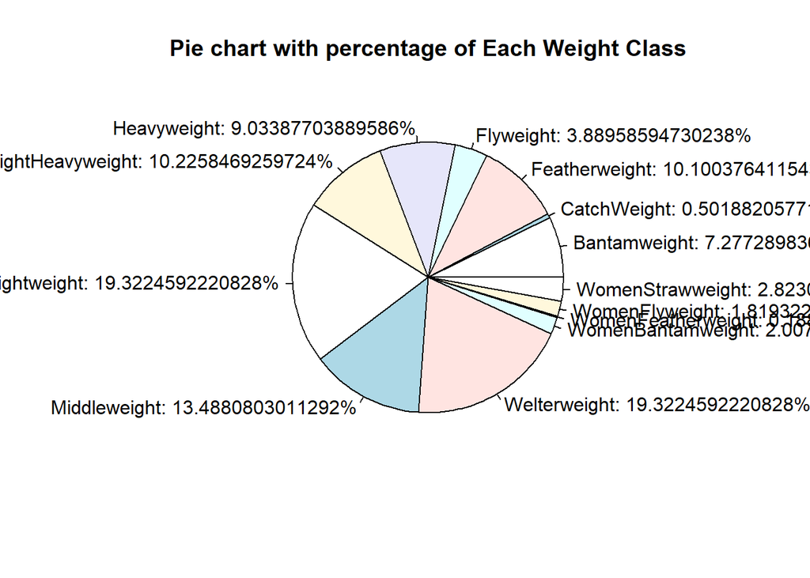

```r
class_type = levels(as.factor(data_reduced$weight_class))
class_percent = 100*table(data_reduced$weight_class)/n
class_lab = paste(class_type, ": ", class_percent, sep='')
class_lab <- paste(class_lab, '%', sep='')

pie(table(data_reduced$weight_class),labels=class_lab, main='Pie chart with percentage of Each Weight Class')
```

We can see that several weight classes only occupy for less than 5%, including flywieght, catchweight (this is actually not a weight class) and every weight class for women. Therefore, we decide to drop all of the weight class less than 5%.

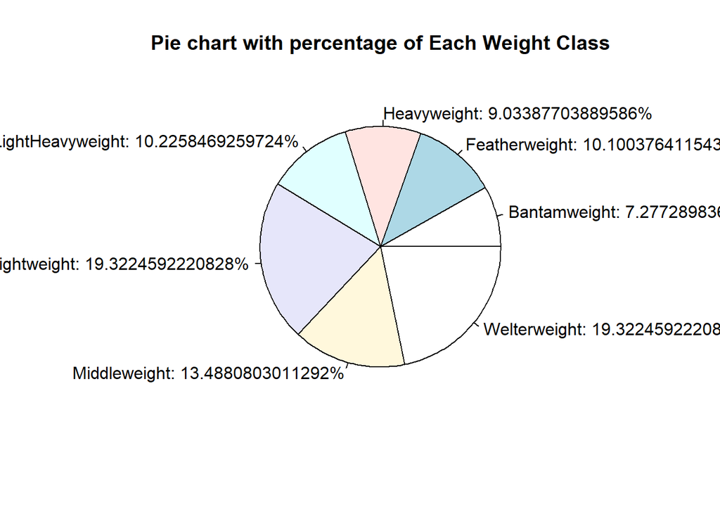

```r
class_drop = c("Fly|Catch|Women")
drop_class = sapply(data_reduced$weight_class, str_detect, regex(class_drop))
data_reduced = data_reduced[!drop_class, ]

class_type = levels(as.factor(data_reduced$weight_class))
class_percent = 100*table(data_reduced$weight_class)/n
class_lab = paste(class_type, ": ", class_percent, sep='')
class_lab <- paste(class_lab, '%', sep='')

pie(table(data_reduced$weight_class),labels=class_lab, main='Pie chart with percentage of Each Weight Class')
```

**Check correlated columns based on background knowledge**

Check correlation between strikes “landed” and “attempted” because these two should be strongly correlated with each other.

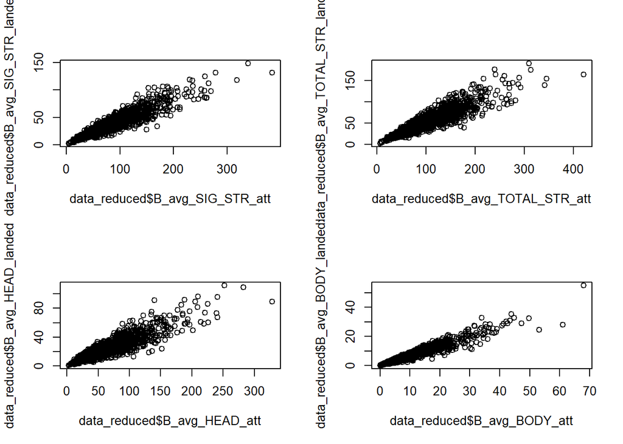

```r
par(mfrow = c(2, 2))
#num_cols= logical(0)
#for(i in 1:ncol(data_reduced)){
#  num_cols = append(num_cols, is.numeric(data_reduced[,i]))
#}
plot(data_reduced$B_avg_SIG_STR_att, data_reduced$B_avg_SIG_STR_landed)
plot(data_reduced$B_avg_TOTAL_STR_att, data_reduced$B_avg_TOTAL_STR_landed)
plot(data_reduced$B_avg_HEAD_att, data_reduced$B_avg_HEAD_landed)
plot(data_reduced$B_avg_BODY_att, data_reduced$B_avg_BODY_landed)
```

```r
cor(data_reduced$B_avg_SIG_STR_att, data_reduced$B_avg_SIG_STR_landed)
```

```
## [1] 0.9223006
```

```r
cor(data_reduced$B_avg_TOTAL_STR_att, data_reduced$B_avg_TOTAL_STR_landed)
```

```
## [1] 0.9024316
```

```r
cor(data_reduced$B_avg_HEAD_att, data_reduced$B_avg_HEAD_landed)
```

```
## [1] 0.8921568
```

```r
cor(data_reduced$B_avg_BODY_att, data_reduced$B_avg_BODY_landed)
```

```
## [1] 0.9554277
```

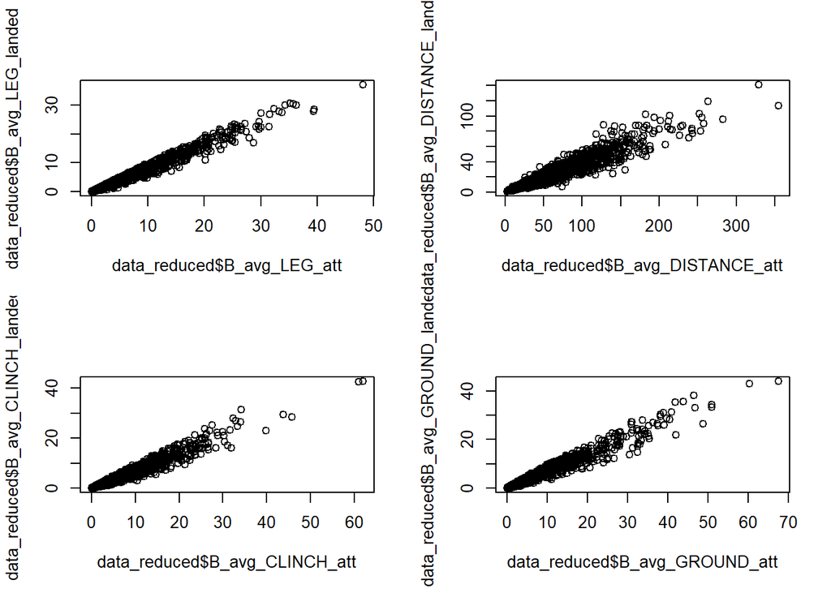

```r
par(mfrow = c(2, 2))
plot(data_reduced$B_avg_LEG_att, data_reduced$B_avg_LEG_landed)
plot(data_reduced$B_avg_DISTANCE_att, data_reduced$B_avg_DISTANCE_landed)
plot(data_reduced$B_avg_CLINCH_att, data_reduced$B_avg_CLINCH_landed)
plot(data_reduced$B_avg_GROUND_att, data_reduced$B_avg_GROUND_landed)
```

```r
cor(data_reduced$B_avg_LEG_att, data_reduced$B_avg_LEG_landed)
```

```
## [1] 0.9845588
```

```r
cor(data_reduced$B_avg_DISTANCE_att, data_reduced$B_avg_DISTANCE_landed)
```

```
## [1] 0.9372816
```

```r
cor(data_reduced$B_avg_CLINCH_att, data_reduced$B_avg_CLINCH_landed)
```

```
## [1] 0.9689018
```

```r
cor(data_reduced$B_avg_GROUND_att, data_reduced$B_avg_GROUND_landed)
```

```
## [1] 0.9743238
```

We can see that any kind of “strikes attempted” is extremely highly correlated to its corresponding “strikes landed”, therefore we remove every “strikes attempted” column.

```r
# Drop "strikes attempted" columns
str_types = c("STR", "HEAD", "BODY", "LEG", "DISTANCE", "CLINCH", "GROUND")
for(i in 1:length(str_types)){
  str = paste(str_types[i], "_att", sep="")
  att_col = sapply(colnames(data_reduced), str_detect, regex(str))
  data_reduced = data_reduced[, !(att_col)]
}
```

Also, since number of significant strikes might be strongly correlated number of total strikes, we check the correlation of them as well.

```r
par(mfrow=c(2, 2))
plot(data_reduced$B_avg_TOTAL_STR_landed, data_reduced$B_avg_SIG_STR_landed)
plot(data_reduced$R_avg_TOTAL_STR_landed, data_reduced$R_avg_SIG_STR_landed)
cor(data_reduced$B_avg_SIG_STR_landed, data_reduced$B_avg_TOTAL_STR_landed)
```

```
## [1] 0.8289291
```

```r
cor(data_reduced$R_avg_SIG_STR_landed, data_reduced$R_avg_TOTAL_STR_landed)
```

```
## [1] 0.8527749
```

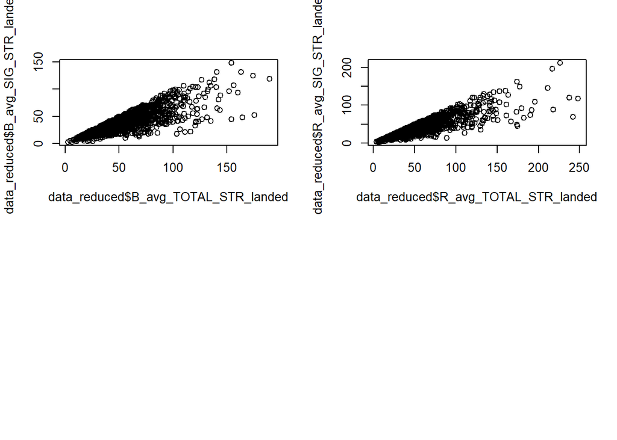

We can see a clear linear relationship between these two, plus number of total strikes is not as important as number of significant strikes, so we drop the number of total strikes.

```r
# Drop columns of # of total strikes
tot_col = sapply(colnames(data_reduced), str_detect, regex("TOTAL_STR"))
data_reduced = data_reduced[, !(tot_col)]
```

Now we check correlation between takedowns “landed” and “attempted”

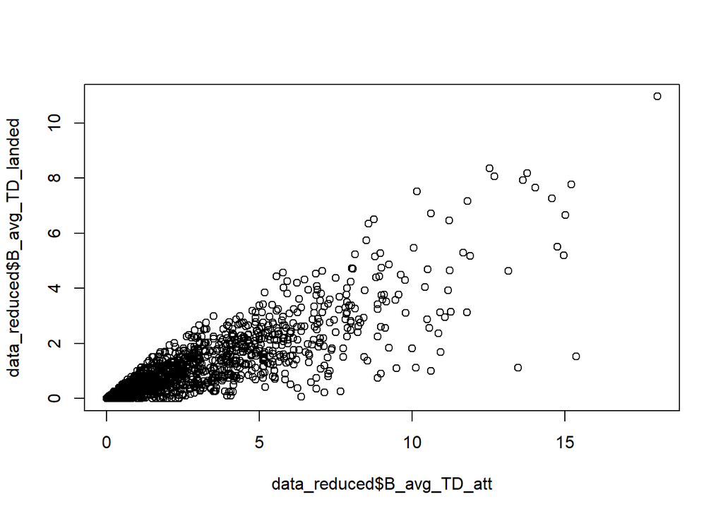

```r
plot(data_reduced$B_avg_TD_att, data_reduced$B_avg_TD_landed)
```

```r
cor(data_reduced$B_avg_TD_att, data_reduced$B_avg_TD_landed)
```

```
## [1] 0.8403524
```

There’s also a clear linear relationship between TD attempted and TD landed.

```r
# Drop columns of # of TD landed
td_land_col = sapply(colnames(data_reduced), str_detect, regex("TD_landed"))
data_reduced = data_reduced[, !(td_land_col)]
```

Also, common sense suggests that the height of one person should be related to his reach, we check these two columns.

```r
par(mfrow = c(2, 2))
plot(data_reduced$B_Height_cms, data_reduced$B_Reach_cms)
plot(data_reduced$R_Height_cms, data_reduced$R_Reach_cms)
cor(data_reduced$B_Height_cms, data_reduced$B_Reach_cms)
```

```
## [1] 0.8475022
```

```r
cor(data_reduced$R_Height_cms, data_reduced$R_Reach_cms)
```

```
## [1] 0.874501
```

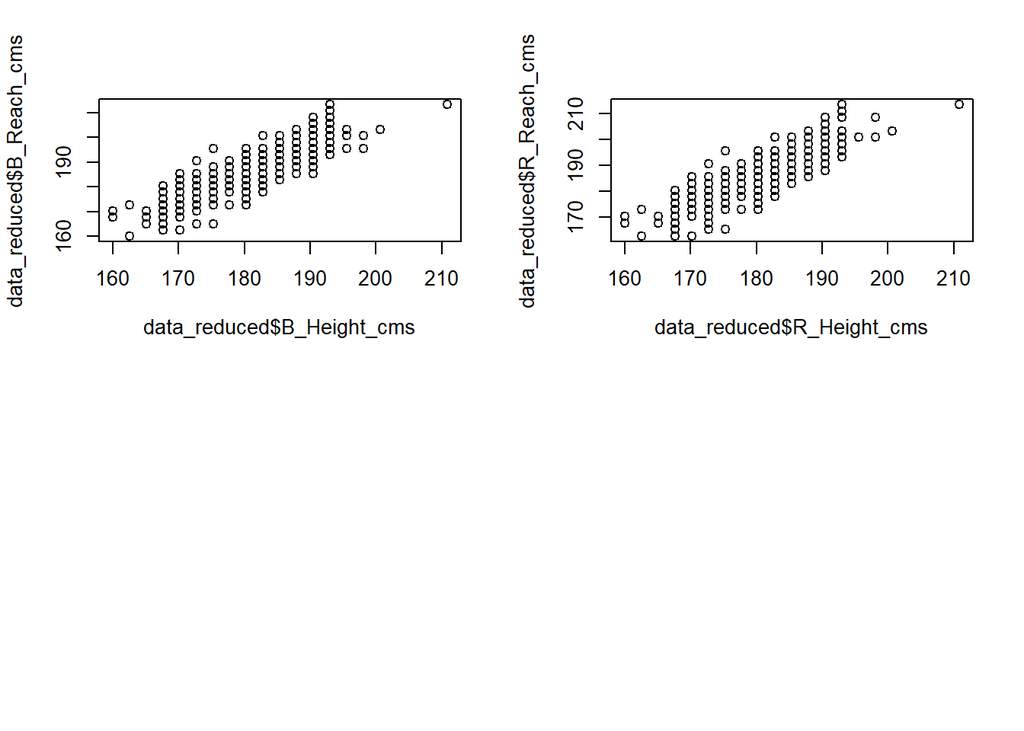

The plots and correlations suggest the same. We now drop the height since it should be somewhat less important than the reach in fighting.

```r
# Drop columns of # of height
tot_col = sapply(colnames(data_reduced), str_detect, regex("Height"))
data_reduced = data_reduced[, !(tot_col)]
```

**Check correlation of the remaining columns**

```r
cor_mat = data.frame(cor(data_reduced[, 3:18]))
for(i in 1:(nrow(cor_mat)-1)){
  for(j in (i+1):(ncol(cor_mat))){
    if(cor_mat[i, j] >= 0.75){
      cat(sprintf("%s & %s: %f\n", rownames(cor_mat)[i], colnames(cor_mat)[j], cor_mat[i, j]))
    }
  }
}
```

```
## B_avg_SIG_STR_landed & B_avg_HEAD_landed: 0.924621
## B_avg_SIG_STR_landed & B_avg_DISTANCE_landed: 0.923348
## B_avg_HEAD_landed & B_avg_DISTANCE_landed: 0.839590
```

We can see that “avg_SIG_STR_landed”, “B_avg_HEAD_landed” and “B_avg_DISTANCE_landed” are strongly correlated. This is because a huge number of the significant strikes happen while both fighters are standing up and keeping a distance, which is the definition of distance strikes. Also, while both fighters are throwing shots at a distance, they mostly target the other fighter’s head. That’s why these three columns are highly correlated. Therefore, We can simply just keep one of them, we choose “B_avg_HEAD_landed” here.

```r
drop_col = sapply(colnames(data_reduced), str_detect, regex("avg_SIG_STR_landed|avg_DISTANCE_landed"))
data_reduced = data_reduced[, !(drop_col)]
```

**Merge columns**

We can merge “current win streak” and “current lose streak” into one column “current streak”, and positive number stands for winning streak and negative number stands for losing streak.

```r
party = c("B", "R")
# Add two new merged columns
for(p in party){
  if(p == "B"){
    B_current_streak = data_reduced$B_current_win_streak + (-1)*data_reduced$B_current_lose_streak
    data_reduced = cbind(data_reduced, B_current_streak)
  }else{
    R_current_streak = data_reduced$R_current_win_streak + (-1)*data_reduced$R_current_lose_streak
    data_reduced = cbind(data_reduced, R_current_streak)
  }
}

# Remove original columns
streak_drop = c("B_current_win_streak", "B_current_lose_streak", "R_current_win_streak", "R_current_lose_streak")
data_reduced = data_reduced[, !(colnames(data_reduced) %in% streak_drop)]
```

Also, since win by majority decision and win by split decision rarely happened, basically we can merge three kind of decision win into one column “win by decision”.

```r
decision_type = c("Majority", "Split", "Unanimous")
# Sum up num of three kind of decision wins of B
B_win_by_Decision = numeric(nrow(data_reduced))
for(type in decision_type){
  B_win_by_Decision = B_win_by_Decision + data_reduced[, paste("B_win_by_Decision_", type, sep = "")]
}
data_reduced = cbind(data_reduced, B_win_by_Decision)

# Sum up num of three kind of decision wins of R
R_win_by_Decision = numeric(nrow(data_reduced))
for(type in decision_type){
  R_win_by_Decision = R_win_by_Decision + data_reduced[, paste("R_win_by_Decision_", type, sep = "")]
}
data_reduced = cbind(data_reduced, R_win_by_Decision)

# Remove original columns
dec_col = sapply(colnames(data_reduced), str_detect, regex("win_by_Decision_"))
data_reduced = data_reduced[, !(dec_col)]
```

**Check the relation between response variable and X variables with boxplots**

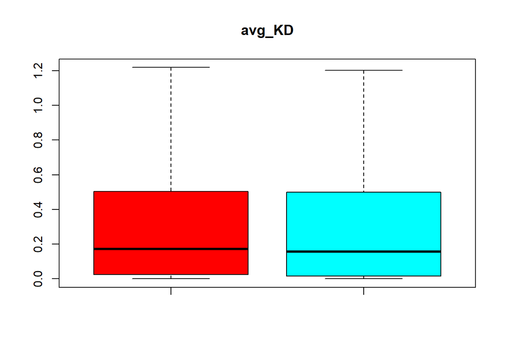

```
## avg_KD ==> Winner: 0.171875 vs Loser: 0.156250
```

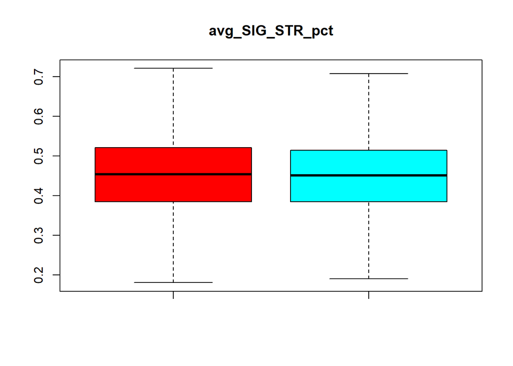

```
## avg_SIG_STR_pct ==> Winner: 0.453750 vs Loser: 0.450781
```

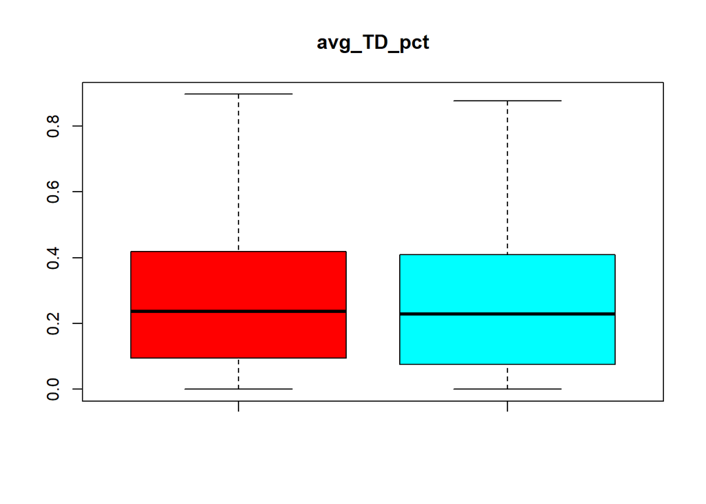

```
## avg_TD_pct ==> Winner: 0.235942 vs Loser: 0.228750
```

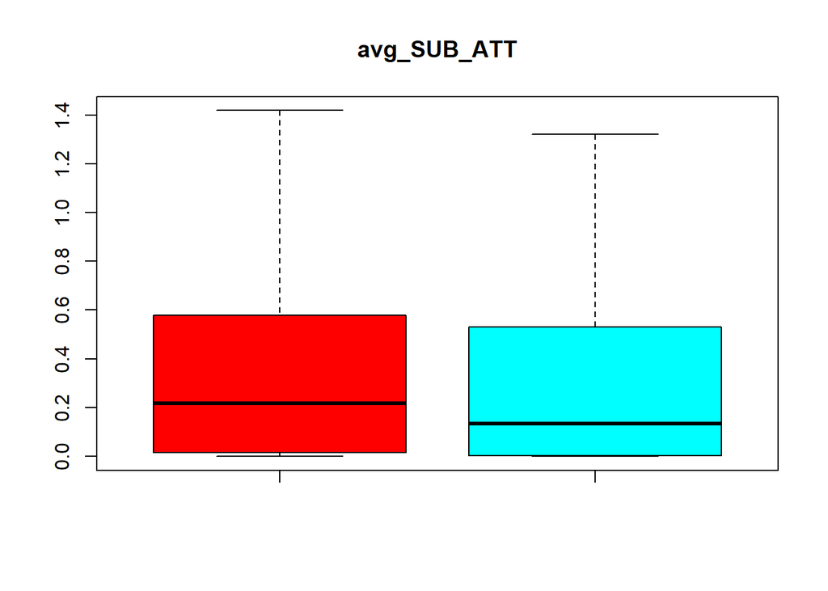

```
## avg_SUB_ATT ==> Winner: 0.218750 vs Loser: 0.133118
```

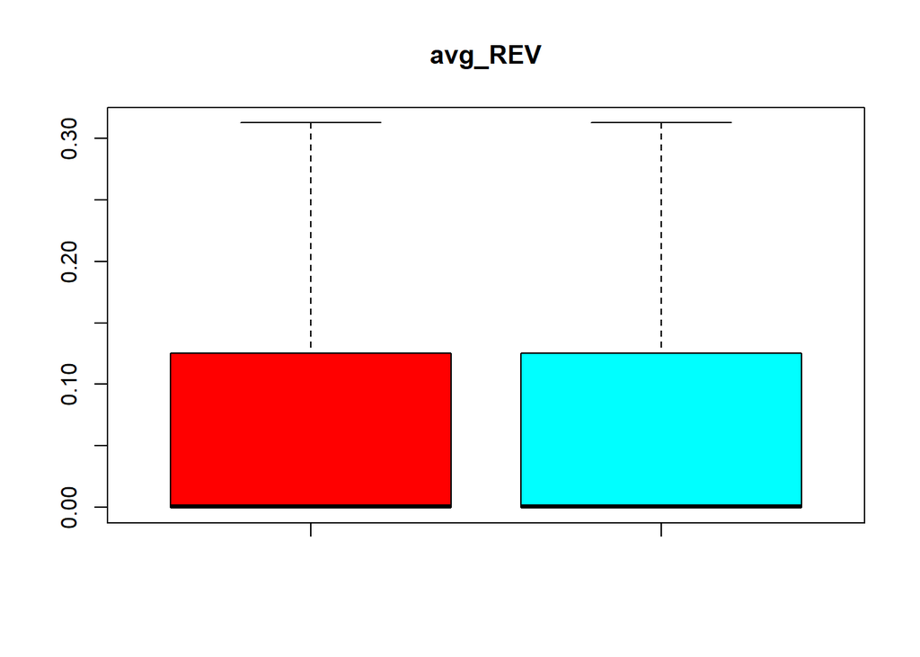

```
## avg_REV ==> Winner: 0.000519 vs Loser: 0.000488
```

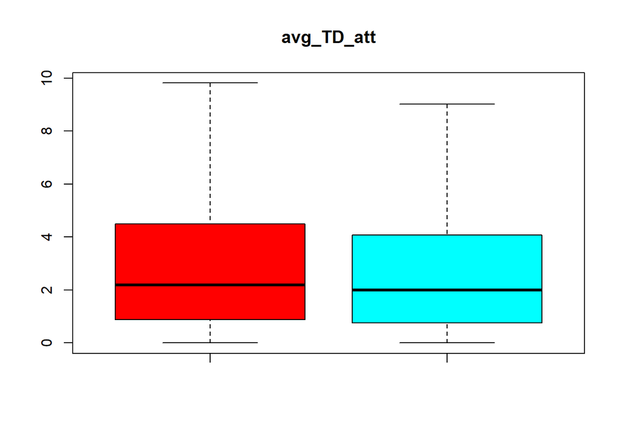

```
## avg_TD_att ==> Winner: 2.182398 vs Loser: 1.989929
```

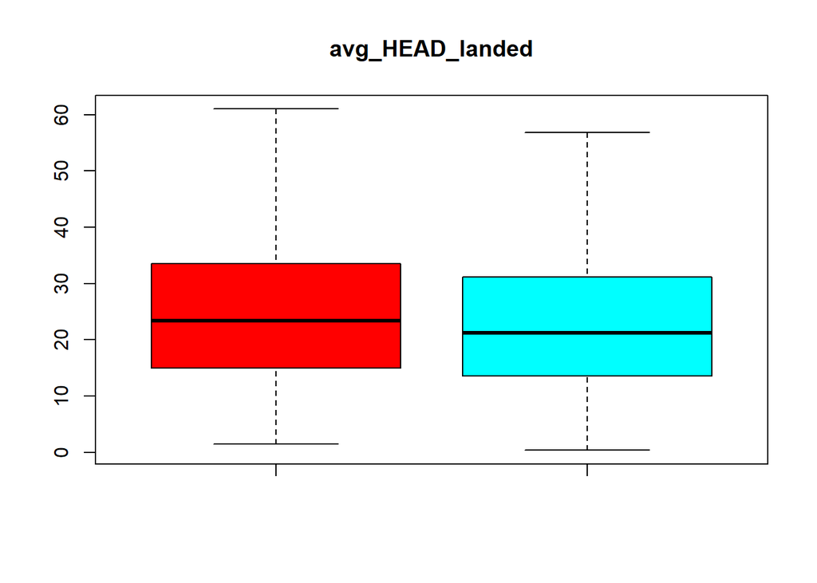

```
## avg_HEAD_landed ==> Winner: 23.329102 vs Loser: 21.187500
```

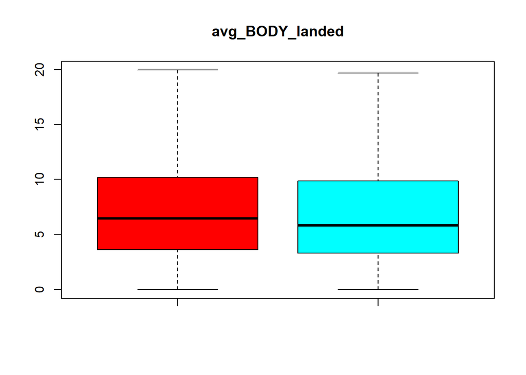

```
## avg_BODY_landed ==> Winner: 6.468750 vs Loser: 5.843750
```

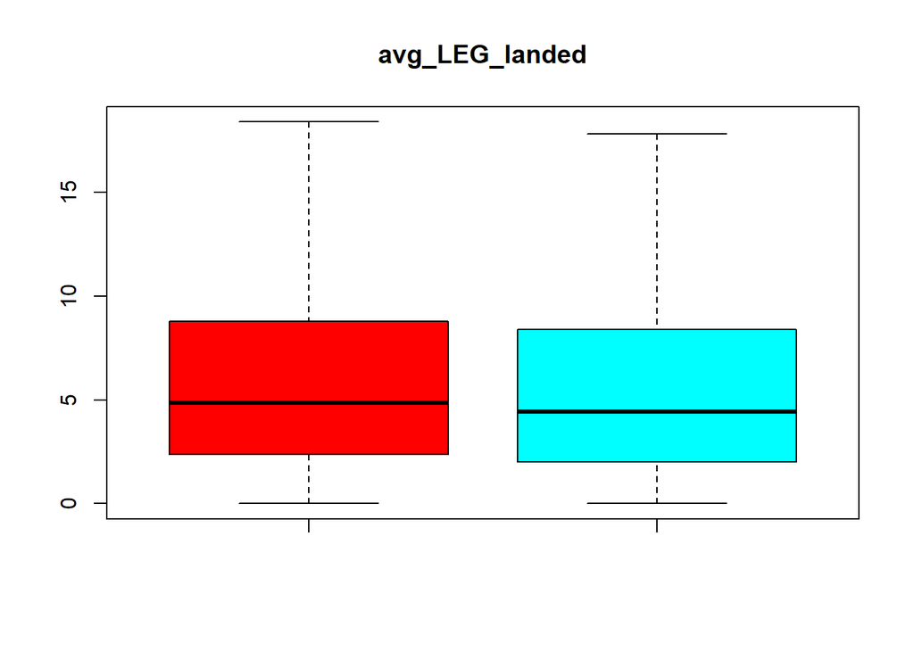

```
## avg_LEG_landed ==> Winner: 4.866455 vs Loser: 4.433228
```

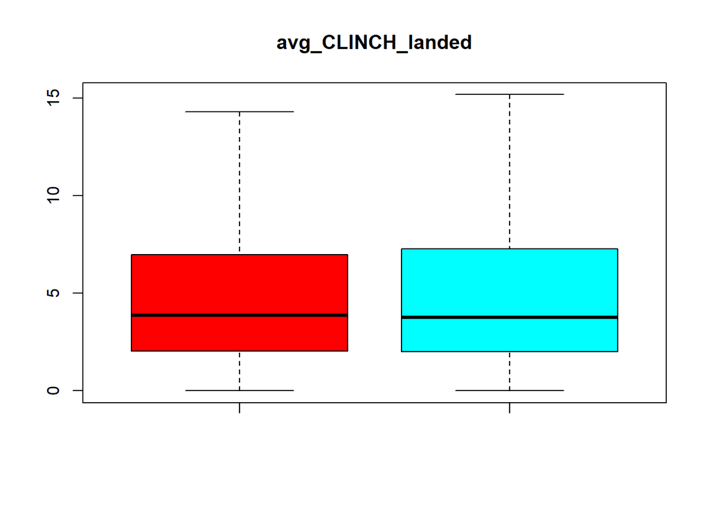

```
## avg_CLINCH_landed ==> Winner: 3.859375 vs Loser: 3.757812
```

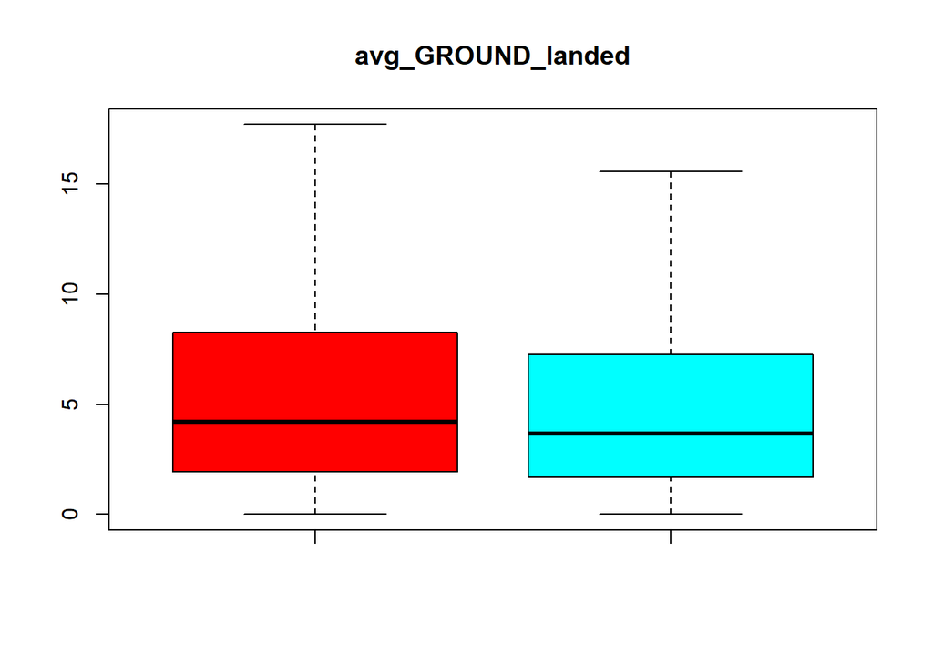

```
## avg_GROUND_landed ==> Winner: 4.213623 vs Loser: 3.656250
```

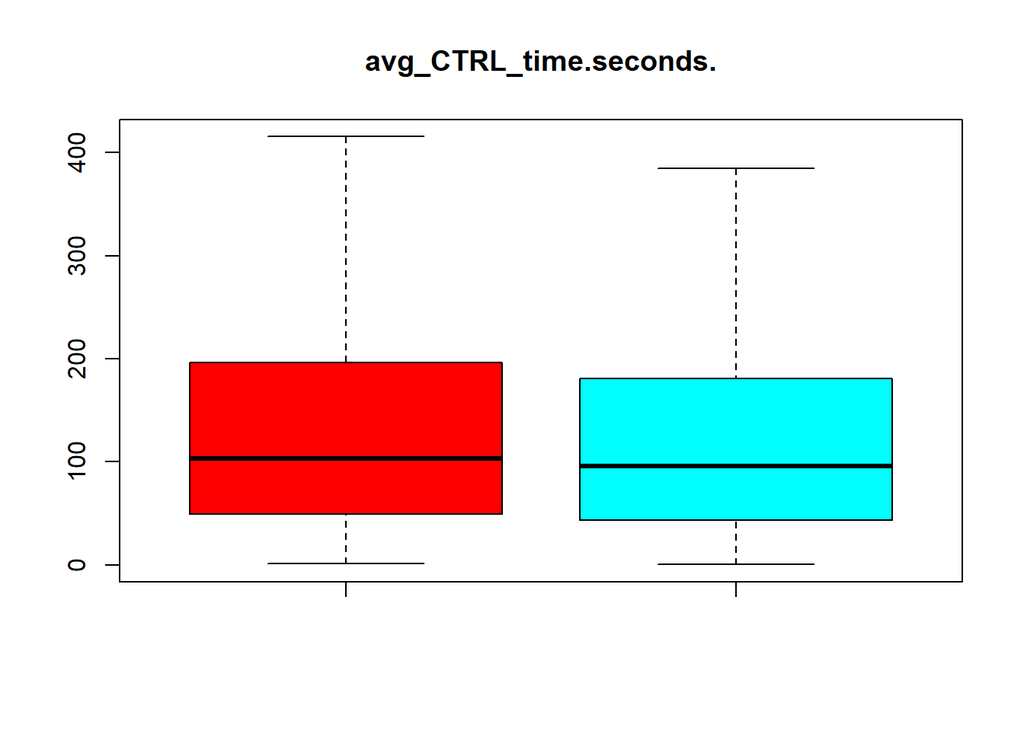

```
## avg_CTRL_time.seconds. ==> Winner: 103.015625 vs Loser: 96.000000
```

[11 more figures not shown]

```
## win_by_Decision ==> Winner: 2.000000 vs Loser: 2.000000
```

```r
data_reduced = data_reduced[, c(1:2, 3:24,47,49,51,25:46, 48,50,52)]
data_swap = data_reduced[, c(1:2, 28:52, 3:27)]
blue_idx = data_reduced$Winner == "Blue"
red_idx = data_reduced$Winner == "Red"
data_swap$Winner[blue_idx] = "Red"
data_swap$Winner[red_idx] = "Blue"
combine_data = rbind(data_reduced, data_swap)

win_lose_data = data_reduced[,3:52]

for(i in 1:nrow(data_reduced)){
  if(data_reduced[i, 1] == "Blue")
    win_lose_data[i,] = data_reduced[i,3:52]
  else
    win_lose_data[i,] = data_reduced[i, c(28:52, 3:27)]
}

for(i in c(1:20, 23:25)){
  boxplot(win_lose_data[,i], win_lose_data[, i+25], main=paste(strsplit(colnames(win_lose_data)[i], "_")[[1]][-1], collapse ="_"), col=rainbow(2), outline=F)
  cat(paste(strsplit(colnames(win_lose_data)[i], "_")[[1]][-1], collapse ="_"))
  cat(sprintf(" ==> Winner: %f vs Loser: %f\n", median(win_lose_data[,i]), median(win_lose_data[, i+25])))
  # boxplot(win_lose_data[,i] - win_lose_data[, i+25], main=paste(strsplit(colnames(win_lose_data)[i], "_")[[1]][-1], sep=""), outline=F)
}
```

After comparing each stat of winners and losers with boxplot, we decide to remove “avg KD”, “avg SIG STR pct”, “avg TD pct”, “avg REV”, “avg CLINCH landed”, “total time fought.seconds.”, “total rounds fought”, “win by KO.TKO”, “win by Submission”, “win by Decision”, “current streak”, “total title bouts”, “wins”, “losses”.

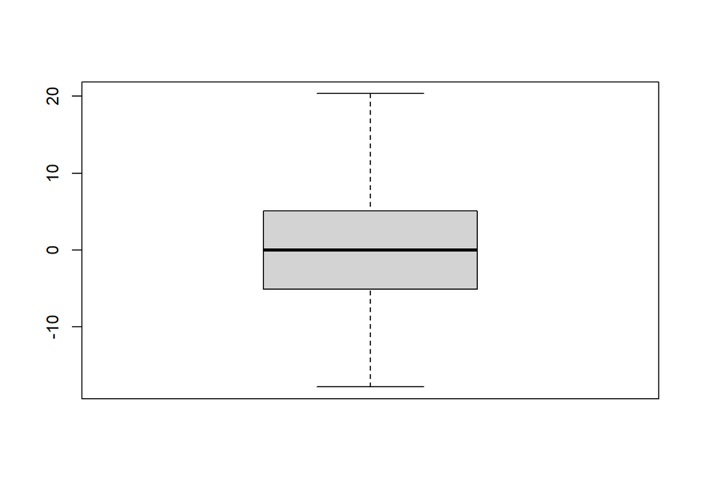

```r
boxplot(win_lose_data[,22] - win_lose_data[, 47], outline=F)
```

```r
cat(median(win_lose_data[,22] - win_lose_data[, 47]))
```

```
## 0
```

We also check the reach difference between winners and losers, it turns out that the reach doesn’t have that much influence since the median of reach difference is zero. Therefore, actually we can just drop the reach and the weight class.

```r
last_drop = c("KD|pct|REV|CLINCH|total|win|loss|Stance|current|Reach|class")
rm_col = sapply(colnames(data_reduced), str_detect, regex(last_drop))
data_reduced = data_reduced[, !(rm_col)]
```

**Write the dataframe into csv file**

```r
filename = "data_predict.csv"
#write.csv(data_reduced, filename, row.names = FALSE)
```